# Modern Regression

2023-03-31

## Elastic Net

Two independent hidden factors \(z_1\) and \(z_2\):

```r
n = 100
z_1 = runif(n,0,20); z_2 = runif(n,0,20)
```

Generate the response as \(y = z_1 + 0.1*z_2 + N(0,1)\)

```r
y = z_1 + 0.1*z_2 + rnorm(n)
```

Observe predictors: \[ x_1 = z_1 + \epsilon_1, x_2 = -z_1 + \epsilon_2, x_3 = z_1 + \epsilon_3 \\ x_4 = z_2 + \epsilon_4, x_5 = -z_2 + \epsilon_5, x_6 = z_2 + \epsilon_6 \]

```r
x_1 = z_1 + rnorm(n); x_2 = -z_1 + rnorm(n); x_3 = z_1 + rnorm(n)
x_4 = z_2 + rnorm(n);x_5 = -z_2 + rnorm(n);x_6 = z_2 + rnorm(n)
x = cbind(x_1,x_2,x_3,x_4,x_5,x_6)
```

## Run Lasso

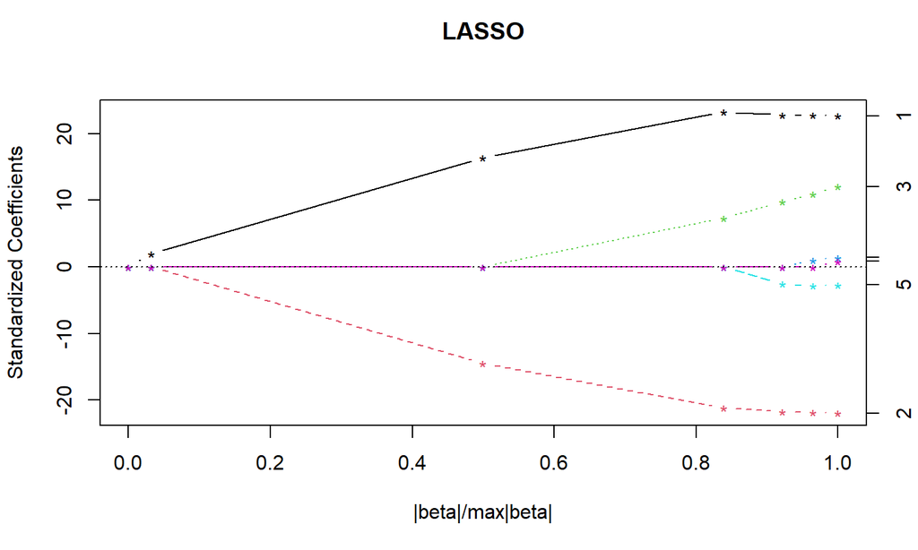

```r
library(lars)
lasso.fit <- lars(x=x,y=y)
plot(lasso.fit, breaks = F)
```

## Run Elastic Net

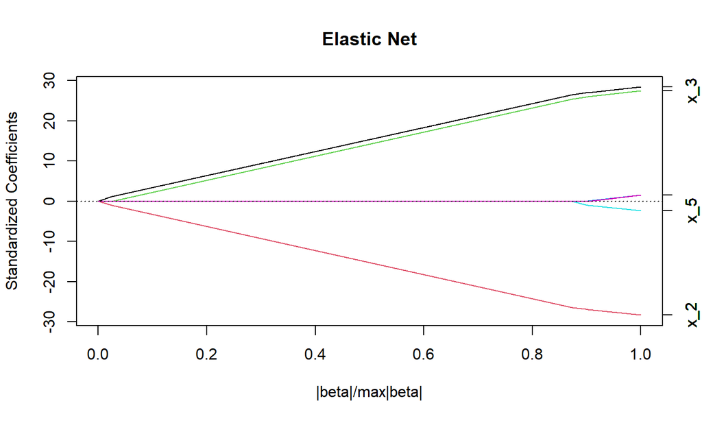

```r
if(!require(elasticnet)){
  install.packages('elasticnet',dependencies=TRUE, repos='http://cran.rstudio.com/')
}
library(elasticnet)
en.fit <- enet(x=x,y=y, lambda = 1)
plot(en.fit, use.color = T, main = "Elastic Net")
```

## Bayesian Regularization

## Bayesian Lasso

- We will look at the same simulation experiment with \(p = 60 > n = 30\) where the parameter vector \(\beta\) is sparse.
- We ask: Does Bayesian Lasso produce the same solution as Lasso?

## Simulation Experiments

- Generate \(X\), \(y\) with \(n = 30, p = 60\) with a sparse \(\beta\) vector with 5 non-zero elements.

```r
library(Matrix)
set.seed(12345)
n=30;p=60
p1 = 5
beta <- c(rep(3,p1),rep(0,p-p1))
x=scale(matrix(rnorm(n*p),n,p))
eps=rnorm(n,mean=0,sd=0.1)
fx = x %*% beta
y=drop(fx+eps)
```

- Our goal is to see if Lasso can recover the 5 non-zero \(\beta\)’s correctly.

## Lasso is sparse

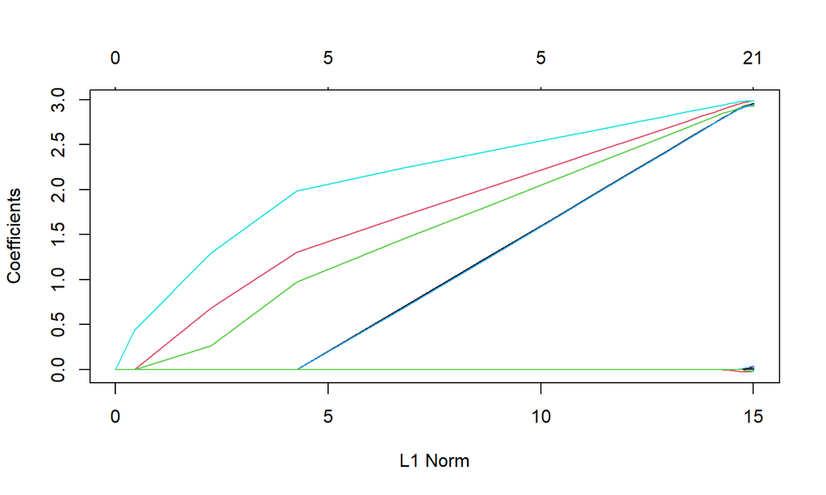

```r
library(glmnet)
grid=10^seq(10,-2,length=100)
lasso.mod =glmnet(x,y,alpha =1,lambda =grid)
plot(lasso.mod)
```

## Choosing Lambda

```r
cv.out =cv.glmnet(x,y,alpha =1)
(bestlam =cv.out$lambda.min)
```

```
## [1] 0.08295634
```

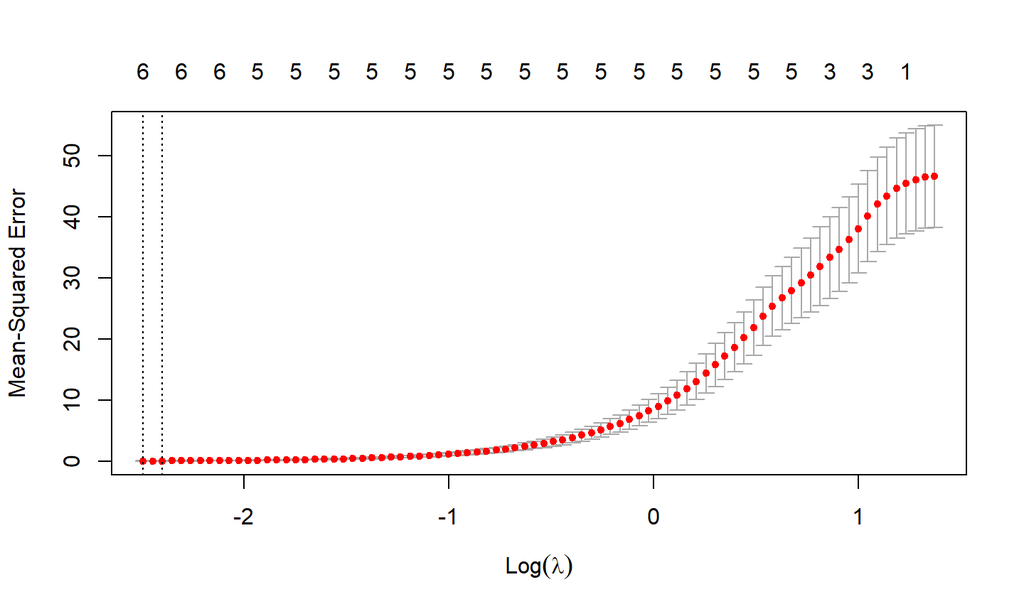

```r
plot(cv.out)
```

## Sparse Solution

```r
lasso.coef=predict(lasso.mod,type ="coefficients",s=bestlam)
lasso.coef[lasso.coef !=0]
```

```
## [1]  0.01459650  2.85670247  2.92947327  2.88166521  2.85101983  2.96229890
## [7] -0.01440246
```

- Use `which` function to get rid of the warning message

```r
lasso.coef[which(lasso.coef!=0)]
```

```
## [1]  0.01459650  2.85670247  2.92947327  2.88166521  2.85101983  2.96229890
## [7] -0.01440246
```

## LASSO correctly recovers the signals

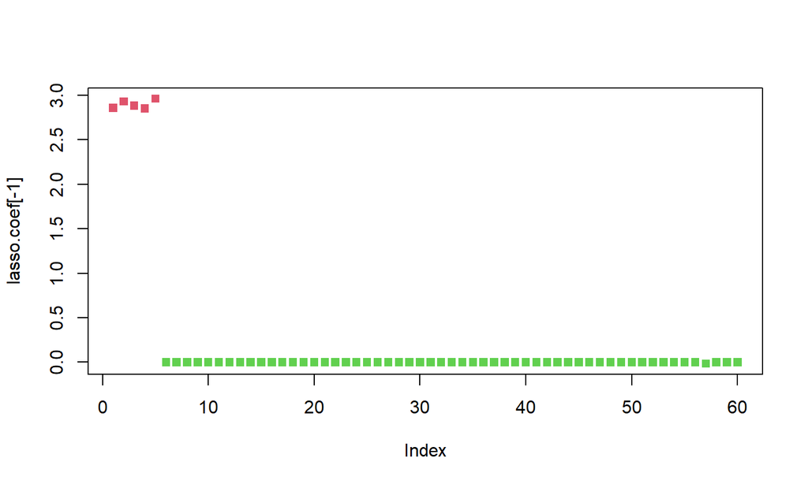

```r
col.index = c(rep(2,p1),rep(3,p-p1))
plot(lasso.coef[-1], col = col.index, pch = 15)
```

## Bayesian Lasso

```r
library(monomvn)
?blasso
```

**Description**

Inference for ordinary least squares, **lasso**/NG, horseshoe and **ridge** regression models by (Gibbs) sampling from the Bayesian posterior distribution, augmented with Reversible Jump for model selection.

```r
blasso(X, y, T = 1000, thin = NULL, RJ = TRUE, M = NULL,
       beta = NULL, lambda2 = 1, s2 = var(y-mean(y)),
       case = c("default", "ridge", "hs", "ng"), mprior = 0, rd = NULL,
       ab = NULL, theta = 0, rao.s2 = TRUE, icept = TRUE,
       normalize = TRUE, verb = 1)
```

## Help

### Description

Inference for ordinary least squares, lasso/NG, horseshoe and ridge regression models by (Gibbs) sampling from the Bayesian posterior distribution, augmented with Reversible Jump for model selection

### Usage

```r
bhs(X, y, T=1000, thin=NULL, RJ=TRUE, M=NULL, beta=NULL,
         lambda2=1, s2=var(y-mean(y)), mprior=0, ab=NULL,
         theta=0, rao.s2=TRUE, icept=TRUE, normalize=TRUE, verb=1)
bridge(X, y, T = 1000, thin = NULL, RJ = TRUE, M = NULL,
       beta = NULL, lambda2 = 1, s2 = var(y-mean(y)), mprior = 0,
       rd = NULL, ab = NULL, theta=0, rao.s2 = TRUE, icept = TRUE,
       normalize = TRUE, verb = 1)
blasso(X, y, T = 1000, thin = NULL, RJ = TRUE, M = NULL,
       beta = NULL, lambda2 = 1, s2 = var(y-mean(y)),
       case = c("default", "ridge", "hs", "ng"), mprior = 0, rd = NULL,
       ab = NULL, theta = 0, rao.s2 = TRUE, icept = TRUE,
       normalize = TRUE, verb = 1)
```

### Arguments

[output not shown]

### Details

The RJ mechanism implemented here for the Bayesian lasso model selection differs from the one described by Hans (2009), which is based on an idea from Geweke (1996). Those methods require departing from the Park & Casella (2008) latent-variable model and requires sampling from each conditional `i | {(-i)},` for all `i`, since a mixture prior with a point-mass at zero is placed on each `_i`. Out implementation here requires no such special prior and retains the joint sampling from the full vector of non-zero entries, which we believe yields better mixing in the Markov chain. RJ proposals to increase/decrease the number of non-zero entries does proceed component-wise, but the acceptance rates are high due due to marginalized between-model moves (Troughton & Godsill, 1997).

When the lasso prior or RJ is used, the automatic thinning level (unless `thin != NULL`) is determined by the number of columns of `X` since this many latent variables are introduced

Bayesian ridge regression is implemented as a special case via the `bridge` function. This essentially calls `blasso` with `case = “ridge”`. A default setting of `rd = c(0,0)` is implied by `rd = NULL`, giving the Jeffery’s prior for the penalty parameter `^2` unless `ncol(X) >= length(y)` in which case the proper specification of `rd = c(5,10)` is used instead.

The Normal–Gamma prior (Griffin & Brown, 2009) is implemented as an extension to the Bayesian lasso with `case = “ng”`. Many thanks to James Scott for providing the code needed to extend the method(s) to use the horseshoe prior (Carvalho, Polson, Scott, 2010).

When `theta > 0` then the Student-t errors via scale mixtures (and thereby extra latent variables `omega2`) of Geweke (1993) is applied as an extension to the Bayesian lasso/ridge model. If Student-t errors are used the automatic thinning level is augmented (unless `thin != NULL`) by the number of rows in `X` since this many latent variables are introduced

### Value

`blasso` returns an object of class `“blasso”`, which is a `list` containing a copy of all of the input arguments as well as of the components listed below.

| `call` | a copy of the function call as used |
| --- | --- |
| `mu` | a vector of `T` samples of the (un-penalized) “intercept” parameter |
| `beta` | a `T*ncol(X)` `matrix` of `T` samples from the (penalized) regression coefficients |
| `m` | the number of non-zero entries in each vector of `T` samples of `beta` |
| `s2` | a vector of `T` samples of the variance parameter |
| `lambda2` | a vector of `T` samples of the penalty parameter |
| `gamma` | a vector of `T` with the gamma parameter when `case = “ng”` |
| `tau2i` | a `T*ncol(X)` `matrix` of `T` samples from the (latent) inverse diagonal of the prior covariance matrix for `beta`, obtained for Lasso regressions |
| `omega2` | a `T*nrow(X)` `matrix` of `T` samples from the (latent) diagonal of the covariance matrix of the response providing a scale-mixture implementation of Student-t errors with degrees of freedom `nu` when… |
| `nu` | a vector of `T` samples of the degrees of freedom parameter to the Student-t errors mode when active (input `theta > 0`) |
| `pi` | a vector of `T` samples of the Binomial proportion `p` that was given a Beta prior, as described above for the 2-vector version of the `mprior` input |
| `lpost` | the log posterior probability of each (saved) sample of the joint parameters |
| `llik` | the log likelihood of each (saved) sample of the parameters |
| `llik.norm` | the log likelihood of each (saved) sample of the parameters under the Normal errors model when sampling under the Student-t model; i.e., it is not present unless `theta > 0` |

### Note

Whenever `ncol(X) >= nrow(X)` it must be that either `RJ = TRUE` with `M <= nrow(X)-1` (the default) or that the lasso is turned on with `lambda2 > 0`. Otherwise the regression problem is ill-posed.

Since the starting values are considered to be first sample (of `T`), the total number of (new) samples obtained by Gibbs Sampling will be `T-1`

### Author(s)

Robert B. Gramacy rbg@vt.edu

### References

Park, T., Casella, G. (2008). *The Bayesian Lasso.*  
Journal of the American Statistical Association, 103(482), June 2008, pp. 681-686  
[doi:10.1198/016214508000000337](https://doi.org/10.1198/016214508000000337)

Griffin, J.E. and Brown, P.J. (2009). *Inference with Normal-Gamma prior distributions in regression problems.* Bayesian Analysis, 5, pp. 171-188.  
[doi:10.1214/10-BA507](https://doi.org/10.1214/10-BA507)

Hans, C. (2009). *Bayesian Lasso regression.* Biometrika 96, pp. 835-845.  
[doi:10.1093/biomet/asp047](https://doi.org/10.1093/biomet/asp047)

Carvalho, C.M., Polson, N.G., and Scott, J.G. (2010) *The horseshoe estimator for sparse signals.* Biometrika 97(2): pp. 465-480.  
https://faculty.chicagobooth.edu/nicholas.polson/research/papers/Horse.pdf

Geweke, J. (1996). *Variable selection and model comparison in regression.* In Bayesian Statistics 5. Editors: J.M. Bernardo, J.O. Berger, A.P. Dawid and A.F.M. Smith, 609-620. Oxford Press.

Paul T. Troughton and Simon J. Godsill (1997). *A reversible jump sampler for autoregressive time series, employing full conditionals to achieve efficient model space moves.* Technical Report CUED/F-INFENG/TR.304, Cambridge University Engineering Department.

Geweke, J. (1993) *Bayesian treatment of the independent Student-t linear model.* Journal of Applied Econometrics, Vol. 8, S19-S40

https://bobby.gramacy.com/r_packages/monomvn/

### See Also

`lm` , `lars` in the lars package, `regress`, `lm.ridge` in the MASS package

### Examples

```r
## following the lars diabetes example
data(diabetes)
attach(diabetes)

## Ordinary Least Squares regression
reg.ols <- regress(x, y)

## Lasso regression
reg.las <- regress(x, y, method="lasso")

## Bayesian Lasso regression
reg.blas <- blasso(x, y)

## summarize the beta (regression coefficients) estimates
plot(reg.blas, burnin=200)
points(drop(reg.las$b), col=2, pch=20)
points(drop(reg.ols$b), col=3, pch=18)
legend("topleft", c("blasso-map", "lasso", "lsr"),
       col=c(2,2,3), pch=c(21,20,18))

## plot the size of different models visited
plot(reg.blas, burnin=200, which="m")

## get the summary
s <- summary(reg.blas, burnin=200)

## calculate the probability that each beta coef != zero
s$bn0

## summarize s2
plot(reg.blas, burnin=200, which="s2")
s$s2

## summarize lambda2
plot(reg.blas, burnin=200, which="lambda2")
s$lambda2


## Not run:
## fit with Student-t errors
## (~400-times slower due to automatic thinning level)
regt.blas <- blasso(x, y, theta=0.1)

## plotting some information about nu, and quantiles
plot(regt.blas, "nu", burnin=200)
quantile(regt.blas$nu[-(1:200)], c(0.05, 0.95))

## Bayes Factor shows strong evidence for Student-t model
mean(exp(regt.blas$llik[-(1:200)] - regt.blas$llik.norm[-(1:200)]))

## End(Not run)

## clean up
detach(diabetes)
```

## Apply Bayesian Lasso to sparse data

```r
library(monomvn)
## Lasso regression
reg.las <- regress(x, y, method="lasso")
## Bayesian Lasso regression
reg.blas <- blasso(x, y)
```

```
## t=100, m=7
## t=200, m=8
## t=300, m=6
## t=400, m=7
## t=500, m=5
## t=600, m=7
## t=700, m=9
## t=800, m=8
## t=900, m=10
```

## Visualize \(\hat{\beta}\)

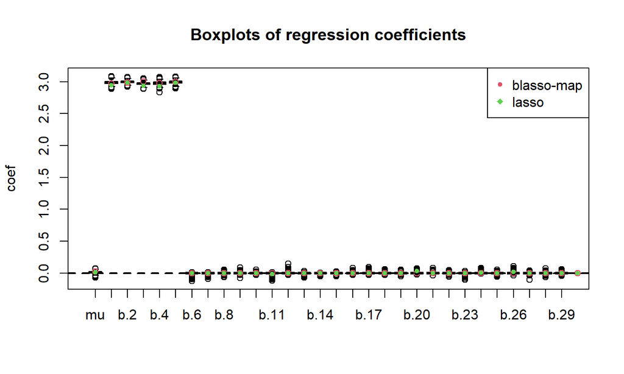

```r
plot(reg.blas, burnin=200)
points(drop(reg.las$b), col=3, pch=20)
legend("topright", c("blasso-map", "lasso"), col=c(2,3), pch=c(20,18))
```

## Model Dimensions

We can plot the size of different models visited:

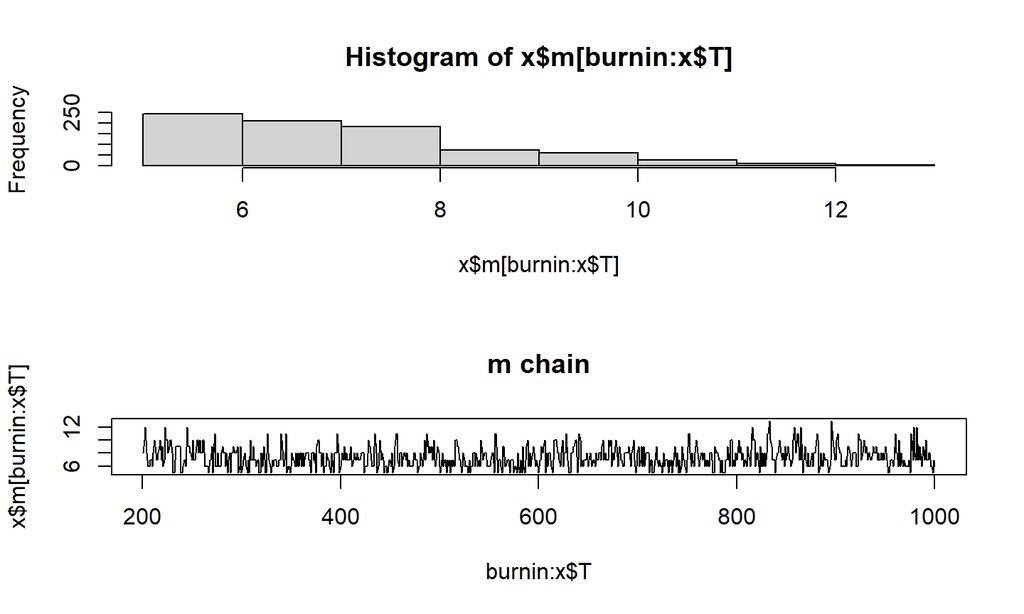

```r
plot(reg.blas, burnin=200, which="m")
```

## Get the summary

The summary contains useful information about the fit.

```r
s <- summary(reg.blas, burnin=200)
names(s)
```

```
##  [1] "call"    "B"       "T"       "thin"    "coef"    "s2"      "lambda2"
##  [8] "tau2i"   "bn0"     "m"
```

## Calculate \(P(\beta_i \ne 0 \mid y_i)\)

This is called posterior inclusion probability.

```r
s$bn0
```

```
##     b.1     b.2     b.3     b.4     b.5     b.6     b.7     b.8     b.9    b.10
## 1.00000 1.00000 1.00000 1.00000 1.00000 0.17875 0.02500 0.02750 0.03500 0.01875
##    b.11    b.12    b.13    b.14    b.15    b.16    b.17    b.18    b.19    b.20
## 0.09625 0.06500 0.03000 0.03125 0.01250 0.02500 0.04250 0.05375 0.02500 0.08125
##    b.21    b.22    b.23    b.24    b.25    b.26    b.27    b.28    b.29    b.30
## 0.01875 0.03625 0.04625 0.12125 0.02875 0.09125 0.03000 0.02500 0.02750 0.01875
##    b.31    b.32    b.33    b.34    b.35    b.36    b.37    b.38    b.39    b.40
## 0.02625 0.03000 0.02375 0.01625 0.02500 0.17125 0.01250 0.01750 0.01875 0.06125
##    b.41    b.42    b.43    b.44    b.45    b.46    b.47    b.48    b.49    b.50
## 0.01375 0.04250 0.03250 0.02250 0.01875 0.03125 0.02250 0.03125 0.03250 0.01250
##    b.51    b.52    b.53    b.54    b.55    b.56    b.57    b.58    b.59    b.60
## 0.03125 0.02250 0.04375 0.02000 0.03625 0.08125 0.08250 0.18375 0.03875 0.02500
```

## Inclusion Prob and Estimates

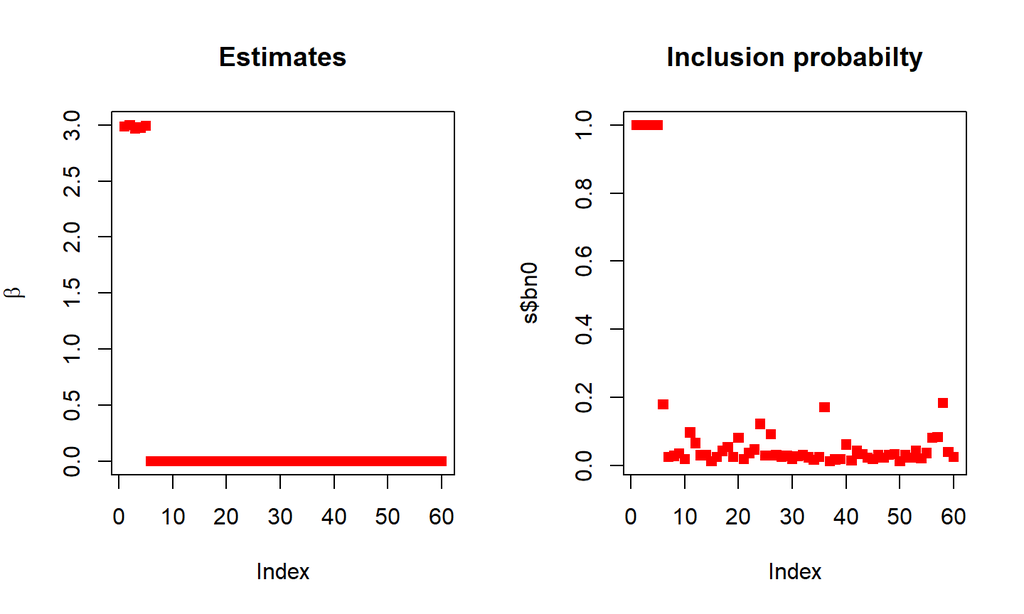

```r
par(mfrow=c(1,2))
plot(apply(reg.blas$beta,2,median),pch=15,col="red", ylab = expression(beta), main = "Estimates")
plot(s$bn0,pch=15,col="red",main = "Inclusion probabilty")
```

## Summarize s2

`s2` is the estimates of the variance parameter.

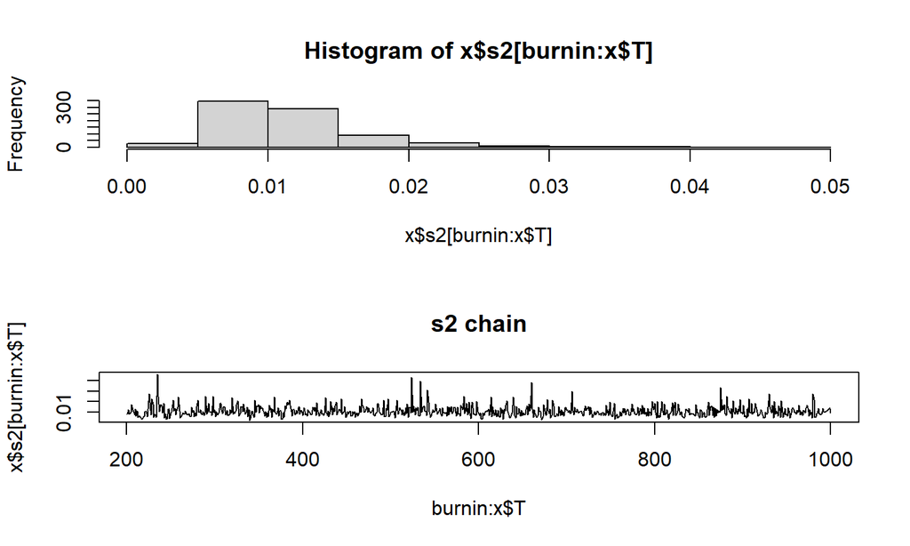

```r
plot(reg.blas, burnin=200, which="s2")
```

```r
s$s2
```

```
##     Min.  1st Qu.   Median     Mean  3rd Qu.     Max.
## 0.002604 0.007799 0.010321 0.011233 0.013492 0.045940
```

## Summarize lambda2

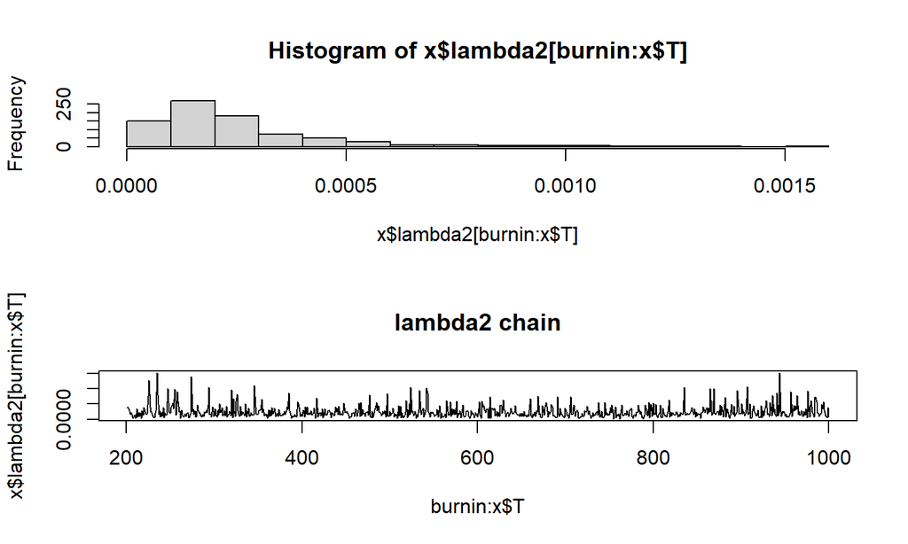

```r
plot(reg.blas, burnin=200, which="lambda2")
```

```r
s$lambda2
```

```
##      Min.   1st Qu.    Median      Mean   3rd Qu.      Max.
## 2.096e-05 1.177e-04 1.936e-04 2.506e-04 3.017e-04 1.515e-03
```

## Bayesian Ridge

```r
## Ridge regression
reg.ridge <- regress(x, y, method="ridge")
## Bayesian Ridge
reg.bridge <- bridge(x, y)
```

```
## t=100, m=5
## t=200, m=6
## t=300, m=6
## t=400, m=5
## t=500, m=9
## t=600, m=8
## t=700, m=6
## t=800, m=6
## t=900, m=8
```

## Visualize \(\hat{\beta}\)

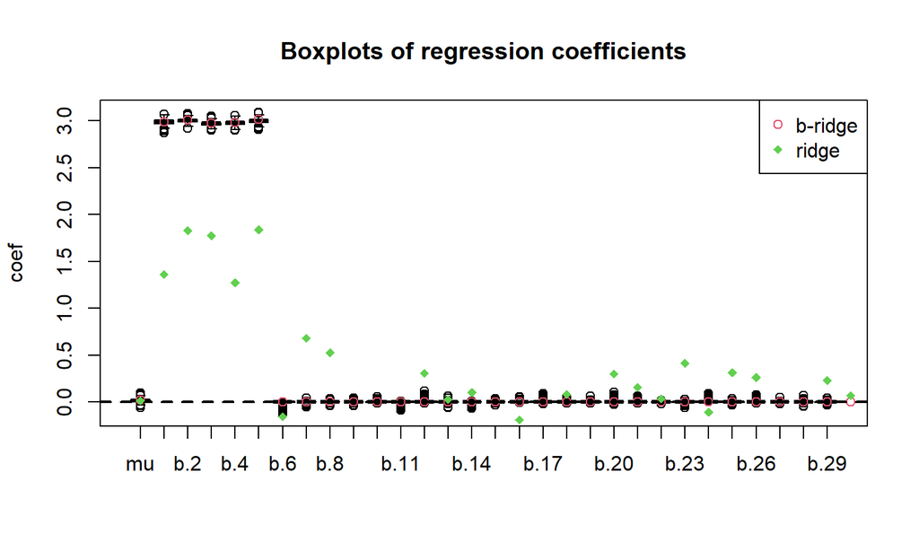

```r
plot(reg.bridge, burnin=200)
points(drop(reg.ridge$b), col=3, pch=18)
legend("topright", c("b-ridge", "ridge"), col=c(2,3), pch=c(21,18))
```

## Model Dimensions

We can plot the size of different models visited:

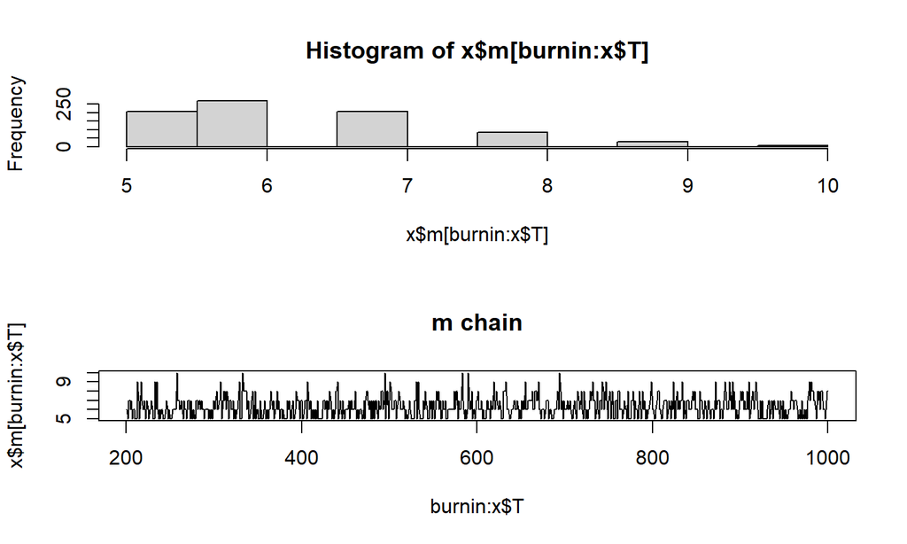

```r
plot(reg.bridge, burnin=200, which="m")
```

## Calculate \(P(\beta_i \ne 0 \mid y_i)\)

This is called posterior inclusion probability.

```r
sridge <- summary(reg.bridge, burnin=200)
sridge$bn0
```

```
##     b.1     b.2     b.3     b.4     b.5     b.6     b.7     b.8     b.9    b.10
## 1.00000 1.00000 1.00000 1.00000 1.00000 0.11875 0.01875 0.01000 0.02125 0.01625
##    b.11    b.12    b.13    b.14    b.15    b.16    b.17    b.18    b.19    b.20
## 0.05125 0.03750 0.01250 0.01500 0.00875 0.01500 0.03500 0.01750 0.00625 0.04625
##    b.21    b.22    b.23    b.24    b.25    b.26    b.27    b.28    b.29    b.30
## 0.01875 0.00625 0.02000 0.07250 0.01250 0.04625 0.01125 0.01500 0.01375 0.02375
##    b.31    b.32    b.33    b.34    b.35    b.36    b.37    b.38    b.39    b.40
## 0.01250 0.00750 0.00875 0.02375 0.02125 0.11125 0.01625 0.01625 0.01250 0.02375
##    b.41    b.42    b.43    b.44    b.45    b.46    b.47    b.48    b.49    b.50
## 0.00625 0.01250 0.00750 0.01125 0.01500 0.01250 0.00750 0.02250 0.01375 0.01625
##    b.51    b.52    b.53    b.54    b.55    b.56    b.57    b.58    b.59    b.60
## 0.01250 0.01375 0.01000 0.01625 0.01125 0.05250 0.03375 0.11875 0.01750 0.01125
```

## Compare

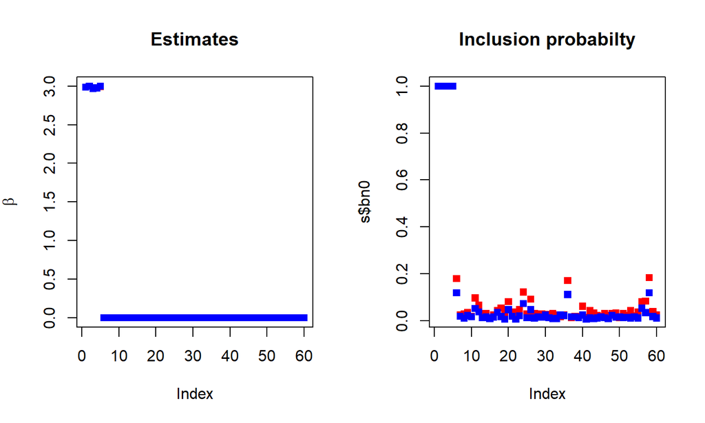

```r
par(mfrow=c(1,2))
plot(apply(reg.blas$beta,2,median),pch=15,col="red", ylab = expression(beta), main = "Estimates")
points(apply(reg.bridge$beta,2,median),pch=15,col="blue")
plot(s$bn0,pch=15,col="red",main = "Inclusion probabilty")
points(sridge$bn0,pch=15,col="blue")
```